# Project: Investigate a Dataset (Replace this with something more specific!)

### dropping unneeded columns for better analysis

```python
#moviesDF = moviesDF.join([df_cast, df_director, df_keywords, df_genres, df_production_companies])
#moviesDF.drop(['cast', 'keywords', 'director', 'production_companies', 'imdb_id', 'homepage', 'tagline'], axis=1,inplace=True)
moviesDF.drop(['imdb_id', 'homepage', 'tagline'], axis=1,inplace=True)
```

### data frame after dropping some columns

```python
moviesDF.head(3)
```

|  | id | popularity | budget | revenue | original_title | cast | director | keywords | overview | runtime | genres | production_companies | release_date | vote_count | vote_average | release_year | budget_adj | revenue_adj |
| --- | --- | --- | --- | --- | --- | --- | --- | --- | --- | --- | --- | --- | --- | --- | --- | --- | --- | --- |
| 0 | 135397 | 32.985763 | 150000000.0 | 1.513529e+09 | Jurassic World | Chris Pratt\|Bryce Dallas Howard\|Irrfan Khan\|Vi... | Colin Trevorrow | monster\|dna\|tyrannosaurus rex\|velociraptor\|island | Twenty-two years after the events of Jurassic ... | 124.0 | Action\|Adventure\|Science Fiction\|Thriller | Universal Studios\|Amblin Entertainment\|Legenda... | 6/9/15 | 5562 | 6.5 | 2015 | 1.379999e+08 | 1.392446e+09 |
| 1 | 76341 | 28.419936 | 150000000.0 | 3.784364e+08 | Mad Max: Fury Road | Tom Hardy\|Charlize Theron\|Hugh Keays-Byrne\|Nic... | George Miller | future\|chase\|post-apocalyptic\|dystopia\|australia | An apocalyptic story set in the furthest reach... | 120.0 | Action\|Adventure\|Science Fiction\|Thriller | Village Roadshow Pictures\|Kennedy Miller Produ... | 5/13/15 | 6185 | 7.1 | 2015 | 1.379999e+08 | 3.481613e+08 |
| 2 | 262500 | 13.112507 | 110000000.0 | 2.952382e+08 | Insurgent | Shailene Woodley\|Theo James\|Kate Winslet\|Ansel... | Robert Schwentke | based on novel\|revolution\|dystopia\|sequel\|dyst... | Beatrice Prior must confront her inner demons ... | 119.0 | Adventure\|Science Fiction\|Thriller | Summit Entertainment\|Mandeville Films\|Red Wago... | 3/18/15 | 2480 | 6.3 | 2015 | 1.012000e+08 | 2.716190e+08 |

### genres column before separating

```python
moviesDF['genres'].head(10)
```

```
0    Action|Adventure|Science Fiction|Thriller
1    Action|Adventure|Science Fiction|Thriller
2           Adventure|Science Fiction|Thriller
3     Action|Adventure|Science Fiction|Fantasy
4                        Action|Crime|Thriller
5             Western|Drama|Adventure|Thriller
6    Science Fiction|Action|Thriller|Adventure
7              Drama|Adventure|Science Fiction
8            Family|Animation|Adventure|Comedy
9                      Comedy|Animation|Family
Name: genres, dtype: object
```

### genres column after separating(in another data frame)

```python
moviesDF_genres=(moviesDF.drop('genres',axis=1)
         .join(moviesDF['genres'].str.split('|', expand=True)
         .stack().reset_index(level=1,drop=True).rename('genres')).loc[:,moviesDF.columns])
moviesDF_genres['genres'].head(10)
```

```
0             Action
0          Adventure
0    Science Fiction
0           Thriller
1             Action
1          Adventure
1    Science Fiction
1           Thriller
2          Adventure
2    Science Fiction
Name: genres, dtype: object
```

### after cleaning check duplication

```python
"""Checking duplicates"""
moviesDF.duplicated().sum()
```

```
0
```

```python
"""Checking if all rows contain the intended data type"""
moviesDF.dtypes
```

```
id                        int64
popularity              float64
budget                  float64
revenue                 float64
original_title           object
cast                     object
director                 object
keywords                 object
overview                 object
runtime                 float64
genres                   object
production_companies     object
release_date             object
vote_count                int64
vote_average            float64
release_year              int64
budget_adj              float64
revenue_adj             float64
dtype: object
```

## Exploratory Data Analysis

> **Tip**: Now that you've trimmed and cleaned your data, you're ready to move on to exploration. Compute statistics and create visualizations with the goal of addressing the research questions that you posed in the Introduction section. It is recommended that you be systematic with your approach. Look at one variable at a time, and then follow it up by looking at relationships between variables.

### before answering some question lets examine our data

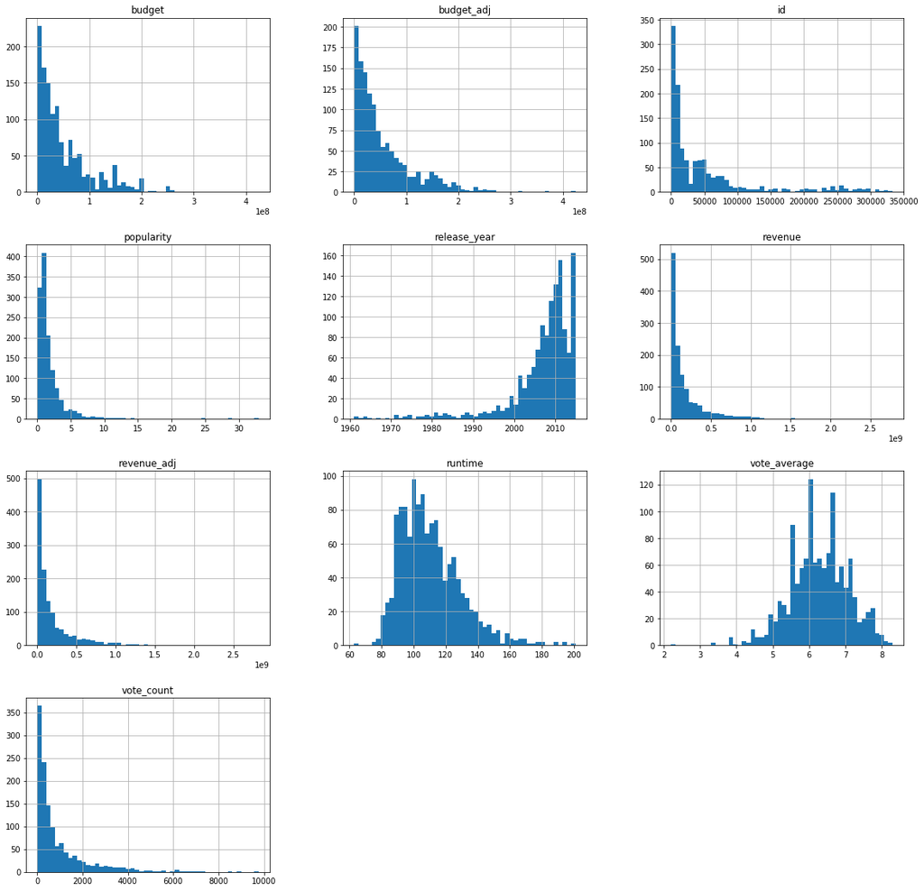

```python
# Use this, and more code cells, to explore your data. Don't forget to add
#   Markdown cells to document your observations and findings.
moviesDF.hist(bins=50 ,figsize = (20,20));
```

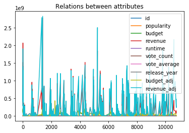

```python
moviesDF.plot(title="Relations between attributes")
```

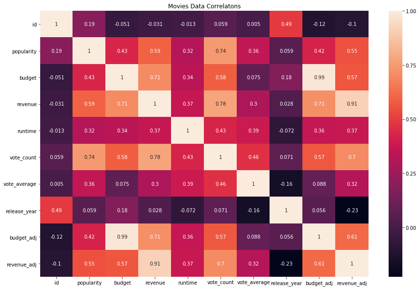

```python
fig, ax = plt.subplots(figsize=(15,10))
seaborn.heatmap(moviesDF.corr(), ax=ax, annot=True);
ax.set_title('Movies Data Correlatons')
```

```python
moviesDF.corr()
```

|  | id | popularity | budget | revenue | runtime | vote_count | vote_average | release_year | budget_adj | revenue_adj |
| --- | --- | --- | --- | --- | --- | --- | --- | --- | --- | --- |
| id | 1.000000 | 0.189301 | -0.050921 | -0.031441 | -0.013123 | 0.059368 | 0.004985 | 0.494397 | -0.116021 | -0.102211 |
| popularity | 0.189301 | 1.000000 | 0.432791 | 0.594755 | 0.322390 | 0.744088 | 0.355904 | 0.059243 | 0.419863 | 0.549299 |
| budget | -0.050921 | 0.432791 | 1.000000 | 0.706888 | 0.337373 | 0.583038 | 0.075168 | 0.179160 | 0.985112 | 0.566835 |
| revenue | -0.031441 | 0.594755 | 0.706888 | 1.000000 | 0.371226 | 0.775374 | 0.296501 | 0.028022 | 0.713706 | 0.913802 |
| runtime | -0.013123 | 0.322390 | 0.337373 | 0.371226 | 1.000000 | 0.426505 | 0.385210 | -0.071863 | 0.361985 | 0.371980 |
| vote_count | 0.059368 | 0.744088 | 0.583038 | 0.775374 | 0.426505 | 1.000000 | 0.464812 | 0.071290 | 0.572798 | 0.703183 |
| vote_average | 0.004985 | 0.355904 | 0.075168 | 0.296501 | 0.385210 | 0.464812 | 1.000000 | -0.163737 | 0.088272 | 0.322503 |
| release_year | 0.494397 | 0.059243 | 0.179160 | 0.028022 | -0.071863 | 0.071290 | -0.163737 | 1.000000 | 0.056174 | -0.228469 |
| budget_adj | -0.116021 | 0.419863 | 0.985112 | 0.713706 | 0.361985 | 0.572798 | 0.088272 | 0.056174 | 1.000000 | 0.613093 |
| revenue_adj | -0.102211 | 0.549299 | 0.566835 | 0.913802 | 0.371980 | 0.703183 | 0.322503 | -0.228469 | 0.613093 | 1.000000 |

### 1.Which movie that have votes more than 1500 in year?

### first:Slice DataFrame to get 2 columns 'vote_count' and 'vote_average'

```python
df_vote = moviesDF.loc[:, 'vote_count' : 'vote_average']
df_vote_1500 = df_vote[df_vote['vote_count'] > 1500]
df_vote_smaller_1500 = df_vote[df_vote['vote_count'] < 1500]
df_vote_2500.head(10)
```

[output not shown]

### check all vote average

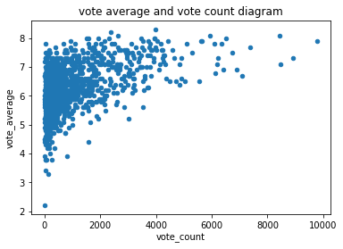

```python
df_vote.plot(x='vote_count', y='vote_average',title="vote average and vote count diagram", kind='scatter');
```

### check it when the vote count more than 1500

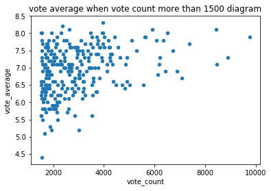

```python
df_vote_1500.plot(x='vote_count', y='vote_average',title="vote average when vote count more than 1500 diagram", kind='scatter');
```

```python
df_vote.corr()
```

|  | vote_count | vote_average |
| --- | --- | --- |
| vote_count | 1.000000 | 0.464812 |
| vote_average | 0.464812 | 1.000000 |

```python
df_vote_1500.corr()
```

|  | vote_count | vote_average |
| --- | --- | --- |
| vote_count | 1.000000 | 0.328937 |
| vote_average | 0.328937 | 1.000000 |

```python
df_vote_smaller_1500.corr()
```

|  | vote_count | vote_average |
| --- | --- | --- |
| vote_count | 1.000000 | 0.283216 |
| vote_average | 0.283216 | 1.000000 |

### We make vote counts less than 1500 and more than 1500 to get the best relation and if it affect or not

```python
# Continue to explore the data to address your additional research
#   questions. Add more headers as needed if you have more questions to
#   investigate.
moviesDF.describe()
```

|  | id | popularity | budget | revenue | runtime | vote_count | vote_average | release_year | budget_adj | revenue_adj |
| --- | --- | --- | --- | --- | --- | --- | --- | --- | --- | --- |
| count | 1287.000000 | 1287.000000 | 1.287000e+03 | 1.287000e+03 | 1287.000000 | 1287.000000 | 1287.000000 | 1287.000000 | 1.287000e+03 | 1.287000e+03 |
| mean | 52557.491064 | 1.786022 | 5.200349e+07 | 1.762444e+08 | 110.273504 | 947.266511 | 6.279487 | 2007.017094 | 5.462994e+07 | 1.991775e+08 |
| std | 74450.077163 | 2.172137 | 5.514540e+07 | 2.538156e+08 | 18.811369 | 1255.476215 | 0.795955 | 8.060503 | 5.525463e+07 | 2.968515e+08 |
| min | 11.000000 | 0.010335 | 1.000000e+00 | 4.300000e+01 | 63.000000 | 10.000000 | 2.200000 | 1961.000000 | 9.693980e-01 | 4.300000e+01 |
| 25% | 5851.500000 | 0.664783 | 1.400000e+07 | 2.565097e+07 | 97.000000 | 179.000000 | 5.800000 | 2005.000000 | 1.519180e+07 | 2.764890e+07 |
| 50% | 20178.000000 | 1.152354 | 3.200000e+07 | 8.208716e+07 | 107.000000 | 439.000000 | 6.300000 | 2009.000000 | 3.556927e+07 | 8.674770e+07 |
| 75% | 62209.500000 | 2.125342 | 7.000000e+07 | 2.140694e+08 | 121.000000 | 1173.000000 | 6.800000 | 2011.000000 | 7.630125e+07 | 2.351178e+08 |
| max | 333348.000000 | 32.985763 | 4.250000e+08 | 2.781506e+09 | 201.000000 | 9767.000000 | 8.300000 | 2015.000000 | 4.250000e+08 | 2.827124e+09 |

## 2.Compare the highest rated movies genre and the produced movies genres in every year

### Get the most watched genres in the year

```python
genres_series = moviesDF_genres.groupby(['release_year'])['genres'].agg(lambda x:x.value_counts().index[0])

#print(genres_series)

#print(comparison_column)

#print(y)
```

```python
vote_average_series = moviesDF_genres.groupby(['release_year'])['vote_average','genres'].agg(lambda x: pd.Series.mode(x)[0])
#print(vote_average_series['genres'])
most_popular_dataFrame=pd.DataFrame({'release_year':genres_series.index, 'genres':genres_series.values,'vote_average':vote_average_series['genres'].values})
#y = moviesDF.groupby(['genres'])['vote_average'].mean()
most_popular_dataFrame.head()
```

|  | release_year | genres | vote_average |
| --- | --- | --- | --- |
| 0 | 1961 | Family | Comedy |
| 1 | 1962 | Adventure | Action |
| 2 | 1963 | Adventure | Action |
| 3 | 1964 | Action | Action |
| 4 | 1965 | Adventure | Action |

```python
comparison_column = np.where(most_popular_dataFrame["genres"] == most_popular_dataFrame["vote_average"], "Matched", "Not Match")
```

### checking for matching(add new column for match)

```python
most_popular_dataFrame["is_match"]=comparison_column
most_popular_dataFrame.head(10)
```

|  | release_year | genres | vote_average | is_match |
| --- | --- | --- | --- | --- |
| 0 | 1961 | Family | Comedy | Not Match |
| 1 | 1962 | Adventure | Action | Not Match |
| 2 | 1963 | Adventure | Action | Not Match |
| 3 | 1964 | Action | Action | Matched |
| 4 | 1965 | Adventure | Action | Not Match |
| 5 | 1967 | Adventure | Action | Not Match |
| 6 | 1969 | Adventure | Action | Not Match |
| 7 | 1971 | Thriller | Thriller | Matched |
| 8 | 1972 | Drama | Crime | Not Match |
| 9 | 1973 | Thriller | Thriller | Matched |

count values of is match columns

```python
most_popular_dataFrame['is_match'].value_counts()
```

```
Matched      39
Not Match    12
Name: is_match, dtype: int64
```

## 3.Which genres have the highest rate?

### the genre and the average rating relation

```python
genres_rates = moviesDF_genres.groupby(['genres'])['vote_average'].mean()
genres_rates_dataFrame=pd.DataFrame({'genres':genres_rates.index, 'vote_average':genres_rates.values})
print(genres_rates_dataFrame)
```

```
             genres  vote_average
0            Action      6.195422
1         Adventure      6.346128
2         Animation      6.417593
3            Comedy      6.113768
4             Crime      6.366839
5       Documentary      6.620000
6             Drama      6.504860
7            Family      6.269939
8           Fantasy      6.250000
9           Foreign      7.800000
10          History      6.614286
11           Horror      5.745324
12            Music      6.368421
13          Mystery      6.303061
14          Romance      6.332653
15  Science Fiction      6.274641
16         Thriller      6.153885
17              War      6.703125
18          Western      6.407692
```

### make bar graph to visualize the difference

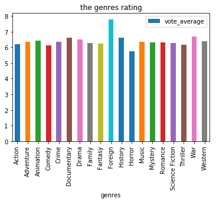

```python
genres_rates_dataFrame.plot('genres',kind='bar',title="the genres rating")
```

## 4.Maximum popularity of movies by years

### plot the popularity of films in every year and show the relation

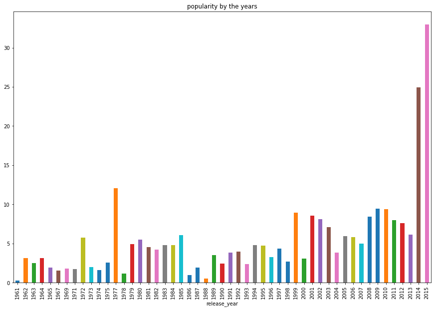

```python
moviesDF.groupby(['release_year'])['popularity'].max().plot(kind='bar',figsize=(15,10),title="popularity by the years")
```

## Conclusions

> **Tip**: Finally, summarize your findings and the results that have been performed. Make sure that you are clear with regards to the limitations of your exploration. If you haven't done any statistical tests, do not imply any statistical conclusions. And make sure you avoid implying causation from correlation!

> **Tip**: Once you are satisfied with your work, you should save a copy of the report in HTML or PDF form via the **File** > **Download as** submenu. Before exporting your report, check over it to make sure that the flow of the report is complete. You should probably remove all of the "Tip" quotes like this one so that the presentation is as tidy as possible. Congratulations!

The hird research question is "Which genres have the highst rating?" and by checking this data we realese that the forigen data take the highest rating with observed diffrence?

All results are limited to the underlying data set and as no advaned statistics were performed, the results can only be treated as indicators and are not generalizable. Furthermore, one has to consider that many entries in the dataset have been removed due to missing data.